# Introdução a Fundos Imobiliários (FIIs)

Ross et al. (2022), capítulo 08

Marcelo S. Perlin

EA-UFRGS

06/05/2026

# Introdução

## O que são FIIs?

> Fundos de Investimento Imobiliário (FIIs) é um contrato típico do mercado de renda variável, onde existe uma comunhão de recursos destinados à aplicação em empreendimentos imobiliários.
- Semelhante a uma ação de uma empresa, o FII é uma forma de investir em imóveis sem precisar comprar um imóvel físico inteiro, pois o patrimônio do fundo é dividido em **cotas**
- O cotista tem direito a receber uma parcela das receitas (aluguéis, juros) proporcional ao número de cotas que possui
- São negociados na bolsa de valores (B3) de forma semelhante a ações

## Imóvel Físico vs. FIIs

- **Liquidez:** FIIs podem ser vendidos em D+2 na bolsa; um imóvel pode levar meses ou anos
- **Fracionamento:** É possível investir com valores muito baixos (ex: R$ 10 ou R$ 100) de forma diversificada
- **Gestão Profissional:** Uma equipe especializada administra os inquilinos e os imóveis
- **Diversificação:** Um único Fundo pode ter dezenas de imóveis com centenas de inquilinos
- **Isenção de IR:** Os rendimentos (dividendos) distribuídos aos cotistas pessoa física são geralmente **isentos** de Imposto de Renda

## Performance de FIIs no longíssimo prazo (USA)

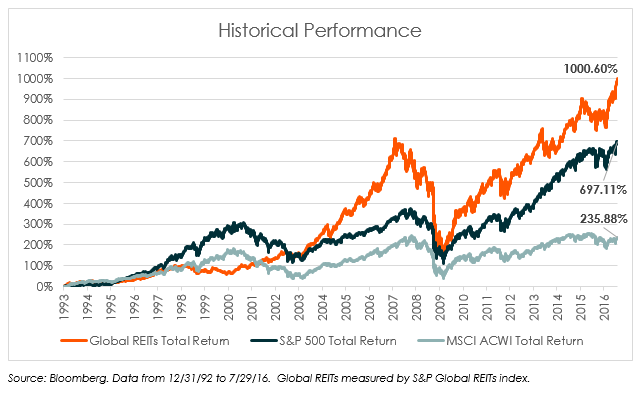

Performance de REITs nos EUA - fonte: [globalxetfs](https://www.globalxetfs.com/articles/reits-a-key-portfolio-building-block)

## Como funciona a Distribuição de Rendimentos?

- Pela lei ([Lei 8.668/93](https://www.planalto.gov.br/ccivil_03/leis/l8668.htm)), os FIIs devem distribuir no mínimo **95% do lucro** apurado em **regime de caixa** a cada semestre
- No entanto, a grande maioria dos fundos opta por realizar distribuições **mensais**
- Essa constância atrai investidores buscando geração de renda passiva (viver de aluguéis)
- A isenção de IR sobre esses proventos mensais é o grande atrativo da classe de ativos no Brasil

# Segmentos e Tipos de FIIs

## Principais Tipologias

**Fundos de Tijolo**

- Investem em imóveis físicos (reais)
- O fundo constrói, adquire ou aluga os imóveis
- Renda majoritariamente dos contratos de aluguel
- Tipos de fundos de tijolos:
  - Lajes corporativas
  - Shoppings
  - Galpões logísticos e industriais
  - Desenvolvimento imobiliário
  - Hotéis

**Fundos de Papel (Recebíveis)**

- Investem em instrumentos financeiros atrelados ao mercado imobiliário (CRI, LCI, etc)
- Fundos agregam dezenas de contratos de dívidas indexadas a taxa de juros e inflação
- Geralmente pagam maior renda (maior *dividend yield*), porém cota não se valoriza tanto quanto os fundos de tijolo

## Fundos de Tijolo: Shopping Centers

- **Portfólio:** Investem na aquisição de participações em Shopping Centers (cotas de shoppings ou propriedades inteiras).
- **Receitas Múltiplas:** aluguéis fixos, aluguéis percentuais (atrelados ao volume de vendas dos lojistas) e da exploração do estacionamento.
- **Sazonalidade:** Apresentam variações de receita ao longo do ano, com picos de distribuição gerados por datas comemorativas (Natal, Dia das Mães, Black Friday).
- **Proteção contra Inflação:** Como as vendas dos lojistas tendem a acompanhar o aumento geral de preços, esses fundos oferecem boa proteção inflacionária.

## Fundos de Tijolo: Galpões Logísticos e Industriais

- **Portfólio:** Investem em grandes galpões logísticos e instalações industriais, fundamentais para a cadeia de suprimentos (ex: e-commerce).
- **Inquilinos e Contratos:** Focam em contratos de aluguel de **longo prazo** (muitas vezes atípicos) com grandes empresas, garantindo maior previsibilidade de receita.
- **Estabilidade de Receita:** Menor rotatividade de inquilinos em comparação a lajes corporativas, devido ao alto custo de mudança de uma operação logística.
- **Risco de Vacância:** Embora o tempo de vacância de um galpão possa ser maior, os contratos longos com pesadas multas rescisórias mitigam esse risco no curto prazo.

# Como avaliar um FII e os seus riscos?

## Indicadores Quantitativos (Tijolo)

1. **DY CAGR, Crescimento Dividendos**: Crescimento do rendimento ao longos dos anos
2. **Tempo de mercado:** Fundos mais novos são mais arriscados (mínimo 5 anos)
3. **Vacância:**: Percentual de vacância (física e financeira). Quanto menor, melhor.
4. **Dividend Yield (DY %):** (Dividendo dos últimos 12 meses / Preço Atual da cota) – CUIDADO, alto DY geralmente é um sinal de algo errado
5. **P/VP (Preço / Valor Patrimonial):** (Valor de Mercado Total / Valor de Avaliação dos Ativos do Fundo). CUIDADO, baixo P/PV geralmente é sinal de algo errado.

## Análise Qualitativa

1. **Poder de reajuste**: Capacidade do fundo de reajustar os aluguéis acima da inflação (ex: contratos atrelados ao IPCA)
2. **Tipo de Inquilino e imóvel:** Empresas sólidas e de grande porte são mais confiáveis. Lajes corporativas são mais arriscadas que galpões logísticos, por exemplo
3. **Vencimento e Tipos de Contrato:** Contratos típicos (3-5 anos) vs. atípicos (10-15 anos com garantias rigorosas)
4. **Gestora e Governança:** O histórico do administrador importa muito. O investidor depende de gestão ética.

## O que pode dar errado?

- **Risco de Vacância:** O inquilino sai, rompendo contrato, e o imóvel fica vazio. Além de perder o aluguel, o fundo passa a pagar condomínio e IPTU.
- **Risco de Inadimplência:** O locatário atrasa ou deixa de pagar o aluguel.
- **Risco de Cotação:** Em momentos de taxa Selic alta, outros rendimentos fixos pagam mais, fazendo a cota dos FIIs se desvalorizar para se tornarem um investimento mais atraente no seu comparativo.
- **Risco Político:** Risco sobre alterações na isenção do IR dos proventos de FIIs na legislação vigente.
- **Risco ambiental:** Risco de desvalorização do imóvel por questões ambientais (ex: enchentes, deslizamentos, etc).

# FIIs na Prática

## XPML11 (Shopping Centers)

- IPO em 2017, 16 shoppings no porfólio
- Foco em imoveis AAA (alta qualidade), em 7 distintos estados do país
- Alta liquidez (média diária de R$ 1,5 milhões)
- Dividend Yield (DY) de 9,91%

## XPML11: Fluxos de caixa

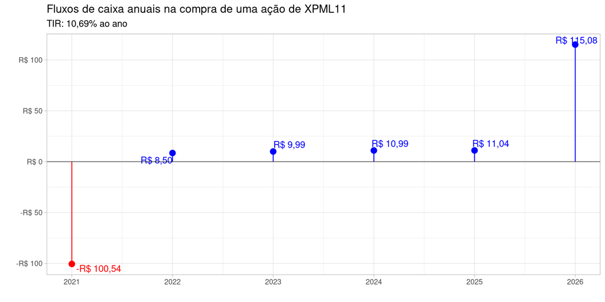

## XPML11: Gráfico dos Rendimentos Anuais

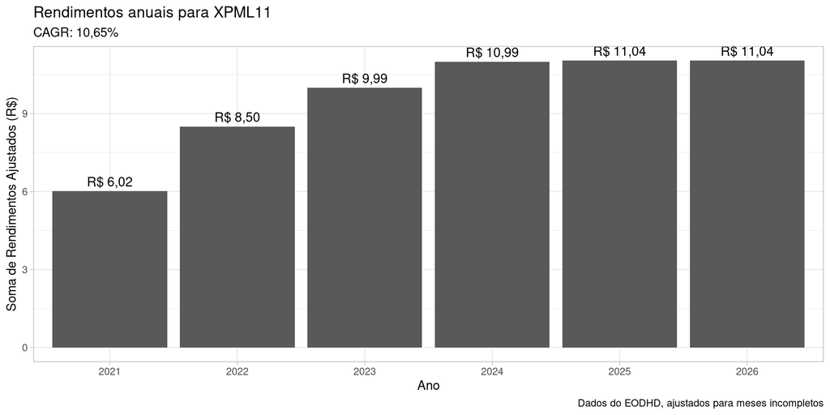

## HGLG11 (Galpões Logísticos)

- Um dos maiores e mais tradicionais FIIs de logística do Brasil (IPO em 2010)
- Portfólio diversificado com dezenas de galpões logísticos e industriais, localizados em pontos estratégicos de distribuição
- Forte concentração na região Sudeste, destacando-se o estado de São Paulo
- Inquilinos de grande porte, abrangendo setores estratégicos como e-commerce, varejo, bens de consumo e automotivo
- Contratos Atípicos, de longíssimo prazo (10-15 anos) e com pesadas multas rescisórias, garantindo alta previsibilidade de receita

## HGLG11: Fluxos de caixa

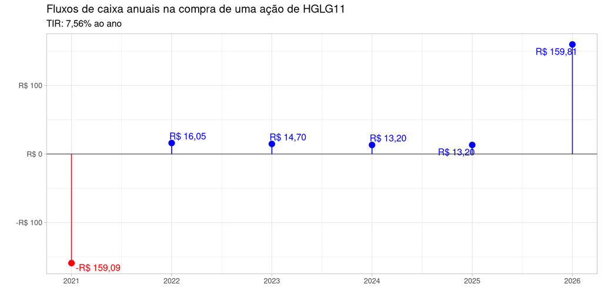

## HGLG11: Gráfico dos Rendimentos Anuais

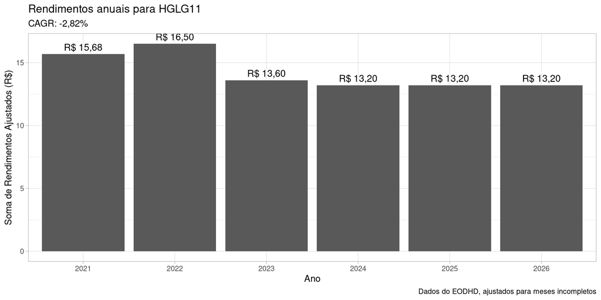

## HGCR11 (Papel)

- Um dos mais tradicionais fundos de recebíveis imobiliários (papel) da B3, gerido pelo CSHG (Credit Suisse Hedging-Griffo)
- Investe predominantemente em Certificados de Recebíveis Imobiliários (CRIs)
- Portfólio diversificado em títulos de dívida atrelados ao setor imobiliário, com indexadores focados em CDI e índices de inflação (IPCA)
- Perfil focado em operações de baixo e médio risco (**High Grade**), oferecendo previsibilidade e distribuição consistente de rendimentos

## HGCR11: Fluxos de caixa

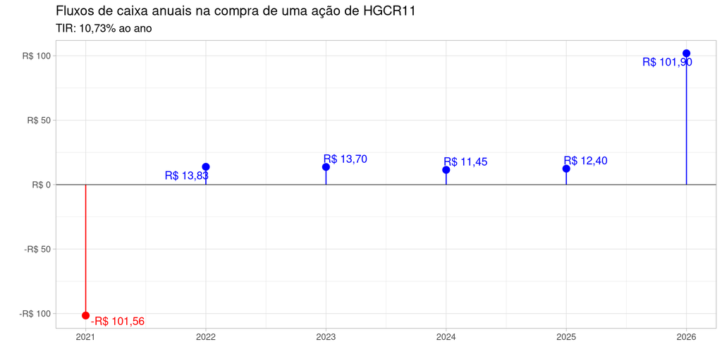

## HGCR11: Gráfico dos Rendimentos Anuais

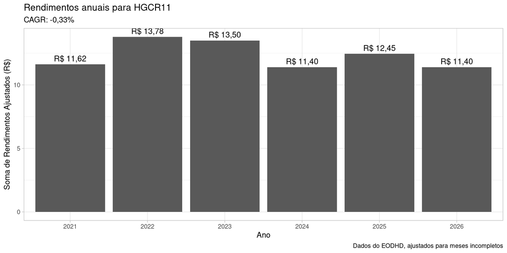

## VINO11 (Edifícios Corporativos)

- Fundo de tijolo gerido pela Vinci Partners, com foco principal em edifícios corporativos (lajes corporativas) de alto padrão.
- Portfólio concentrado em prédios de escritórios bem localizados em regiões estratégicas e *premium*, principalmente nas cidades de São Paulo e Rio de Janeiro.
- O VINO11 utilizou muita dívida para adquirir imóveis. Com o aumento da taxa Selic de 2% para 13,75%, o custo dessa dívida disparou e rendimentos diminuíram.

## VINO11: Fluxos de caixa

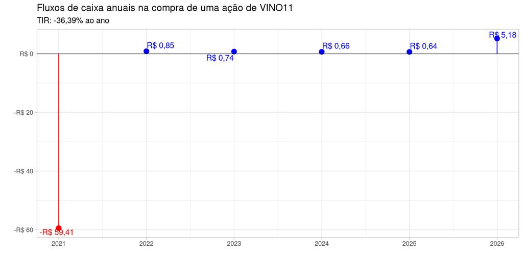

## VINO11: Gráfico dos Rendimentos Anuais

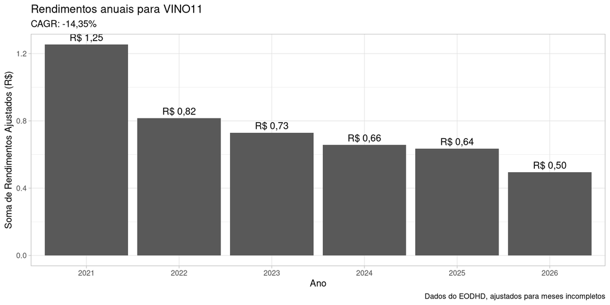

## Evolução de Preços da Cota na Bolsa

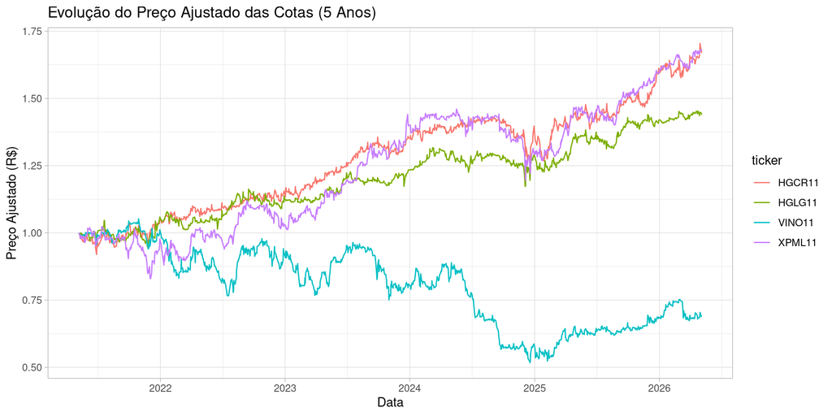

## Retornos de diferentes FIIs

Estatísticas de Retorno e Risco dos FIIs

Período: 07/05/2021 a 05/05/2026

[output not shown]

## Conclusão

- FIIs democratizaram o acesso a imóveis comerciais de alta qualidade (Padrões Triple A) para todos os brasileiros.
- São consistentes e excelentes geradores de **renda passiva mensal isenta**.
- Como são Renda Variável, exigem controle emocional durante as oscilações de mercado e **foco no longo prazo**.
- O reinvestimento dos dividendos durante os primeiros anos (Fase de Acumulação) constrói ativamente o poderoso efeito de ganhos dos *juros compostos*.

## Referências

Ross, Stephen, Randolph Westerfield, Bradford Jordan, et al. 2022. *Fundamentos de Administração Financeira*. Bookman Editora.